# Java Development Kit

È il *pacchetto di software* fondamentale per poter utilizzare il linguaggio di programmazione Java. Il Java Development Kit è edicato agli sviluppatori, contiene una copia del Java Runtime Environement utile per eseguire le applicazioni e tutti gli strumenti necessari per realizzare dei programmi.

Il primo passo per poter utilizzare il tuo computer per scrivere ed eseguire dei programmi in Java consiste nell’installare il pacchetto JDK.

## Verificare la presenza di JRE e JDK

Prima di iniziare il procedimento di installazione verifica se JRE e/o JDK sono già installate sul computer. Per verificare la presenza della JRE apri la shell (powershell, terminal) e digita il comando:

```
java -version
```

Se viene stampata la versione di Java la JRE è presente, ad esempio:

```
java version "15.0.1" 2020-10-15
...
```

Per verificare la versione della JDK digita:

```
javac -version
```

Se viene stampata la versione di Java (ad esempio `javac 15.0.1`) hai la JDK, altrimenti devi installarla.

**Nota**: Se JDK e o JRE è già installato sul tuo computer ma la versione dei software è obsoleta (inferiore a `14.0`), è fortemente consigliato aggiornarli. Al momento della stesura di questo testo la versione corrente del JDK è `17.0.1`.

## Scaricare JDK

Una copia del file di installazione del JDK dovrebbe trovarsi nell’archivio in cui è contenuto questo documento (`jdk-17_windows-x64_bin.exe`); se ce l’hai puoi saltare al capitolo seguente “Installare JDK”.

Se non possiedi il file di installazione puoi scaricarlo dal [sito Oracle](https://www.oracle.com/java/technologies/downloads/#jdk17-windows). Nella sezione `Java SE Development Kit 17.0.1` scegli il file adatto (*installer*) al tuo sistema operativo/processore (*piattaforma*) e poi accetta i termini della licenza:

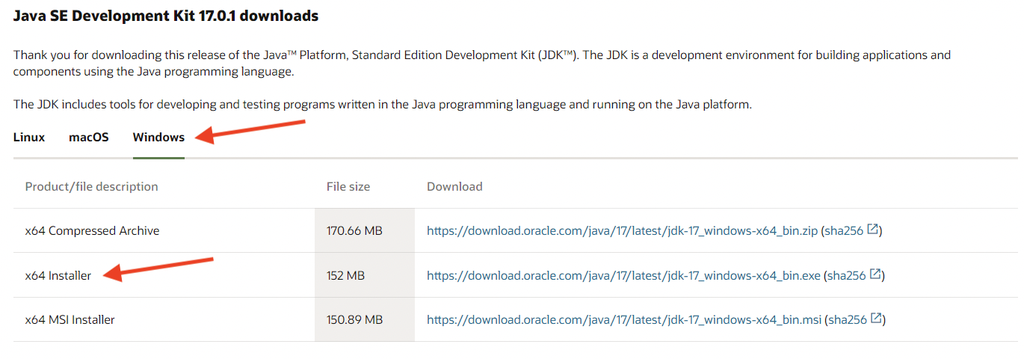

## Installare JDK

Leggi le istruzioni specifiche per la tua piattaforma che trovi sul [sito Oracle](https://docs.oracle.com/en/java/javase/17/install/installation-guide.pdf)

Poi esegui l’*installer* e, una volta terminato il procedimento di installazione, verifica nuovamente la versione di JRE e JDK. Dovrebbe essere `17.0.1`.